# Coursework Report

*N* removed NAs: 2

*N* removed typo: 1

*N* removed <18: 18

*N* total clean: 129

| Group | *N* | *M*<sub>age</sub> | *M*<sub>rating</sub> |
| --- | --- | --- | --- |
| Control | 67 | 20.66 | 6.61 |
| Experim | 62 | 21.00 | 5.73 |

**Main analysis results**

*t*(127) = 6.8, *p* < .001

[interactive chart not shown]

[figure not shown]

[interactive chart not shown]

# Coursework Report

Analysing Data, Spring 2020

# Methods

## Participants

```
## # A tibble: 2 x 5
##   GROUP            n  perc mean_age sd_age
##   <fct>        <int> <dbl>    <dbl>  <dbl>
## 1 control         67  51.9     20.7   2.16
## 2 experimental    62  48.1     21     2.28
```

## Design

The conceptual hypothesis for this study is, does colour effect attractiveness? Colour is the independent, categorical variable with two levels, red (experimental) and white (control). It is also the predictor in this study. The dependent and continuous variable is perceived attractiveness, which will be a rating measurement on a nine point scale, ranging from not at all attractive to extremely attractive. The study will also be independent groups design. A significantly higher score on either condition indicates that colour does impact a woman’s perceived attractiveness, while a similar score suggests that it does not. The operational hypothesis for this study is that there will be a difference in a woman’s perception of a man’s attractiveness measured on a 9 point rating scale across three questions, depending on whether the black and white photo shown of his head and upper torso has a red or white frame. I will use the independent t-test to statistically analyse these results.

# Results

I first investigated whether colour influences women’s perceived attraction of men by creating an individual composite score for each participant, which depicted the mean score from all three questions. I then used this data to create a one means plot of composite score by colour group, which showed that the mean rating of perceived attractiveness was higher in the control group than the experimental. Next, I conducted an independent *t*-test which highlighted that the mean score of the red (experimental) condition was significantly lower than the mean score of the white (control) condition (*M*<sub>diff</sub> = 0.89, 95% CI [0.63, 1.14]), and also that there was a significant difference between the two groups on rating of attraction (*t* (127) = 6.8, *p* = .0000000). This implies that, as predicted, colour does impact perceived attractiveness, but more specifically suggests that colour may actually decrease perceived attractiveness.

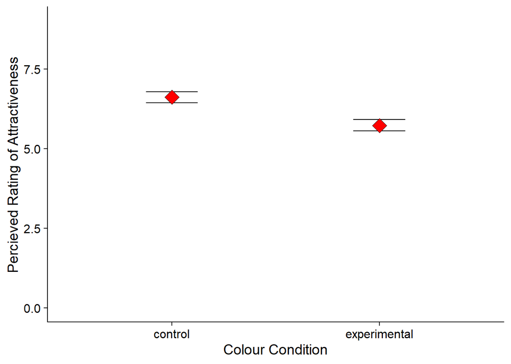

# Discussion

The findings of this study support the conceptual hypothesis that colour effects attractiveness, however they suggest that colour may decrease attraction, contradicting the original study it replicates, which found that participants in the red condition, compared with those in the white condition, rated the target man as more attractive (M=6.79,SD=1.00, and M=5.67,SD=1.34), (Elliot et al, 2010). As this study used only twenty one participants, our new research with a larger sample size of 129 participants provides more accurate mean values and a smaller margin of error, therefore implying that the original study may lack validity or be skewed by outliers. These new findings also question the replicability and temporal validity of the original paper, as it was conducted a decade ago. Alternatively, the contrast between these two sets of results could be due to a lack of validity in both studies, as the colour may be effecting people in different ways. Therefore a preliminary test to identify those influenced by colour in other areas could help give a clearer picture as to whether red specifically effects levels of perceived attraction as opposed to other factors such as kindness, perceived aggression or speed of judgement. A more representative sample could then be created which would lead to more valid results. Despite this, the current study is reasonably successful in testing the hypothesis due to its strong quantitative methodology and independent groups design, however although the sample size is larger than the initial study, it is still reasonably small and therefore not very representative.

Other studies in this field contradict the idea that the colour red increases perceived attractiveness, one paper suggesting that Elliot’s original study was contaminated with publication bias and that some experiments with null findings were either not reported or reported experiments were run improperly in a way that inflated the likelihood of rejecting the null hypothesis (Francis, 2012). The contradictory findings of my experiment supports this claim and indicates that colour is unlikely to increase attraction in a larger sample size, as the results were so opposing. Another study replicated an experiment that found evidence of the red effect with a substantially larger sample size or American men and found no evidence of the red effect (Peperkoorn, 2016). Although this could be a result of gender differences, it also highlights the issues with using a small sample size and how vital it is for results to be representative. Therefore these new results may be flawed and would potentially show no difference in perceived attraction had the sample been larger.

In conclusion, I think it is unlikely that the red effect is real, however research into this area could have huge positive implications, particularly for retail and advertising companies. Therefore it is important to research this topic with larger sample sizes of cross cultural participants to form a truly representative set of results. Future studies should also use preliminary testing to make sure red does not dramatically effect participants in other areas, e.g. perceived aggression, as this could cause misleading findings.

# References

Elliot, A. J., Niesta Kayser, D., Greitemeyer, T., Lichtenfeld, S., Gramzow, R. H., Maier, M. A., & Liu, H. (2010). Red, rank, and romance in women viewing men. Journal of Experimental Psychology: General, 139(3), 399–417. https://doi.org/10.1037/a0019689

Francis, G. (2013). Publication bias in “Red, rank, and romance in women viewing men,” by Elliot et al. (2010). Journal of Experimental Psychology: General, 142(1), 292–296. https://doi.org/10.1037/a0027923

Peperkoorn, L. S., Roberts, S. C., & Pollet, T. V. (2016). Revisiting the Red Effect on Attractiveness and Sexual Receptivity: No Effect of the Color Red on Human Mate Preferences. Evolutionary Psychology, 14(4), 1474704916673841. https://doi.org/10.1177/1474704916673841